# Investment-DataScience_Society_S19

An archive of the scripts, files, and scratch code created and used for the joint project between BYUI’s Data Science Society and Investment Society, Spring semester 2019. An insignificant portion of the original private repository was left out to honor the confidentiality agreement signed by those who participated. Roughly 95% of the work here is my own.

The goal of this project was to automate the procedure of a local financial services firm in which fundamental data for some publicly traded company (a stock) was collected, manually organized in a spreadsheet, and used to manually create various charts and graphs; all of this was achieved in Excel. We wished to create a dashboard using R’s “Shiny” package that would automatically display these data and visualizations for any stock of the user’s choosing. Such an application would save the company significant time that would otherwise be used to painstakingly construct these results in Excel, and as such could save the company whatever money is regularly invested in this inefficient process.

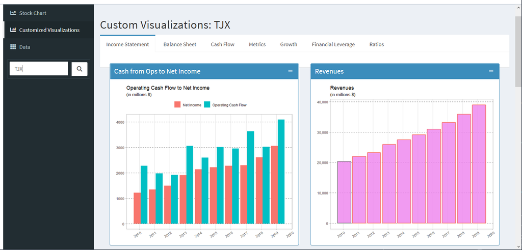

Dashboard screenshot: “Customized Visualizations”

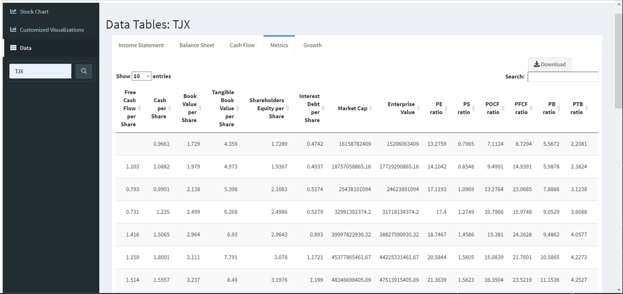

Dashboard screenshot: “Data”